# Financial Reporting

Kevin Putschko

November 18, 2019

## Introduction

In this document, we’re going to pull stock information from the past two weeks for the **GSPC** stock symbol. We’re using the package `tidyquant` to easily pull this stock data from *Yahoo Finance*.

## Stock Performance

The following table was created using the experimental `gt` package. This package allows us to create headers, footers, references, while also formatting each column and adjusting the style as needed.

We can easily pull values from this table and use it in this paragraph using R functions in the background. For example, the most recent date, 2019-11-15, opened at $3,107.92 and closed at $3,120.46. These values will update on their own, and I’ll never have to update this paragraph.

GSPC

2019-11-03 to 2019-11-18

| Date | Open | High | Low | Close | Volume<sup>1</sup> |
| --- | --- | --- | --- | --- | --- |
| 15 Nov 2019 | $3,107.92 | $3,120.46 | $3,104.60 | $3,120.46 ▲ | 3.34B |
| 14 Nov 2019 | $3,090.75 | $3,098.20 | $3,083.26 | $3,096.63 ▲ | 3.28B |
| 13 Nov 2019 | $3,084.18 | $3,098.06 | $3,078.80 | $3,094.04 ▲ | 3.51B |
| 12 Nov 2019 | $3,089.28 | $3,102.61 | $3,084.73 | $3,091.84 ▲ | 3.47B |
| 11 Nov 2019 | $3,080.33 | $3,088.33 | $3,075.82 | $3,087.01 ▲ | 3.04B |
| 8 Nov 2019 | $3,081.25 | $3,093.09 | $3,073.58 | $3,093.08 ▲ | 3.50B |
| 7 Nov 2019 | $3,087.02 | $3,097.77 | $3,080.23 | $3,085.18 ▼ | 4.14B |
| 6 Nov 2019 | $3,075.10 | $3,078.34 | $3,065.89 | $3,076.78 ▲ | 4.46B |
| 5 Nov 2019 | $3,080.80 | $3,083.95 | $3,072.15 | $3,074.62 ▼ | 4.49B |
| 4 Nov 2019 | $3,078.96 | $3,085.20 | $3,074.87 | $3,078.27 ▼ | 4.15B |

## Charts

The following **candlestick** chart shows us the closing price of GSPC over the last 10 years. This chart was created using functions from the `tidyquant` package.

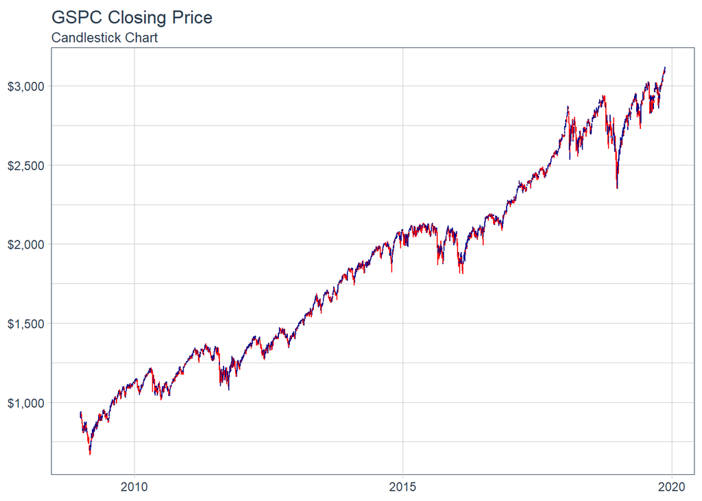

## Conclusion

R Markdown is easiest to use when output is stored as HTML. In this way, RMD is useful for creating dashboards, websites, digital books, and HTML based presentations.